# Assignment 14

Shawn Schneidereit

17.2.2021

**note** that the .Rmd can be found on my [personal repo](https://github.com/schneidereits/Quantitative_Methods_HU/tree/main/assignments) for the course

## Climate station data for Germany

For this exercise we will use long-term average climate station data from the German Meteorological Service (DWD). Monthly and yearly average precipitation (mm) data are available for the period 1981 and 2010.

http://www.dwd.de/DE/leistungen/klimadatendeutschland/langj_mittelwerte.html

ftp://ftp-cdc.dwd.de/pub/CDC/

In this exercise, you are asked to create precipitation maps for the state of Brandenburg from weather station data using two different methods: 1) inverse distance weighted interpolation, and 2) ordinary kriging. Plot and compare the results/maps and semi-variograms.

### 1. Create a SpatialPointsDataFrame.

Create a SpatialPointsDataFrame from the precipitation dataset `"nieder_1981-2010_aktStandort.csv"`. The precipitation dataset contains longitude (column `x`) and latitude (column `y`). The coordinate reference system is geographic WGS-84 (EPSG code 4326). In proj4 format this can be written as `"+init=epsg:4326"`. To analyze spatial distances you need to transform this dataset to an equal area projection, e.g. `"+init=epsg:3035"`. Note, use only the station data from Brandenburg (see `state` column).

```r
# Managing and manipulating vector data
library(sp)
# Reading and writing spatial data
library(rgdal)
```

```r
# Reading and manipulating raster data
library(raster)
# Map visualization
library(mapview)
# Spatial analysis and modeling utilities
library(spatialEco)
# Managing and manipulating vector data
library(sf)
library(gstat)


#import data
rain <- read_csv("~/Documents/humbolt/quantitative_methods/pc_lab/data/nieder_1981-2010_aktStandort.csv")
head(rain)
```

```
## # A tibble: 6 x 19
##   station_name station_id elevation     y     x state   jan   feb   mar   apr
##   <chr>             <dbl>     <dbl> <dbl> <dbl> <chr> <dbl> <dbl> <dbl> <dbl>
## 1 AACHEN-ORSB…      15000     231    50.8  6.02 Nord…    78    72    72    59
## 2 ABBENSEN             12      61    52.4 10.2  Nied…    60    46    56    42
## 3 AFFING               37     470    48.5 11.0  Baye…    46    42    54    54
## 4 AHAUS(AWST)        7374      45.5  52.1  6.93 Nord…    78    61    70    48
## 5 AHAUSEN              39      29    53.1  9.32 Nied…    72    54    64    44
## 6 AHLEN I_W_           42      70    51.8  7.87 Nord…    68    52    64    44
## # … with 9 more variables: mai <dbl>, jun <dbl>, jul <dbl>, aug <dbl>,
## #   sept <dbl>, oct <dbl>, nov <dbl>, dec <dbl>, year <dbl>
```

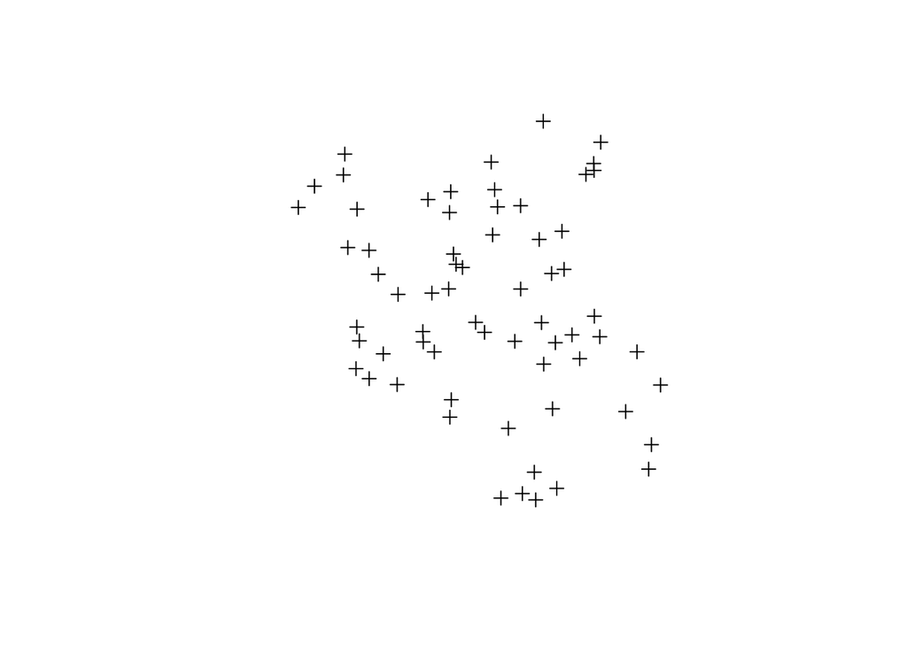

```r
# filter for brandenburg
rain <- rain %>%
  dplyr::filter(state == "Brandenburg")

#creating seperate df
rain_df <- rain


coords <- rain[ , c("x", "y")]
coords_sp <- SpatialPoints(coords, CRS("+proj=longlat +datum=WGS84 +no_defs +ellps=WGS84 +towgs84=0,0,0"))
# vis abies occurance
#proj4string(rain) <- CRS("+init=epsg:4326")

rain_sp <- SpatialPointsDataFrame(coords = coords, data=rain_df,
                                  proj4string = CRS("+proj=longlat +ellps=WGS84 +datum=WGS84 +towgs84=0,0,0"))


# transforming the abies data to an equal area projection
rain_sp <- spTransform(rain_sp, crs("+init=epsg:3035"))

plot(rain_sp)
```

```r
# for some reason I am getting a library error that I cant quite figure out and that has no help online. later one Mapview seems to work just fine though.
#mapview::mapview(rain_sp)
#mapview(rain_sp, zcol="year")
```

### 2. Create a map of annual precipitation (column `year`) using Inverse Distance Weighted Interpolation.

```r
xnew <- seq(rain_sp@bbox[1, 1], rain_sp@bbox[1, 2], length.out = 50)
ynew <- seq(rain_sp@bbox[2, 1], rain_sp@bbox[2, 2], length.out = 50)

gridnew <- expand.grid(xnew, ynew)

gridnew <- SpatialPixels(points=SpatialPoints(gridnew),
                         proj4string = CRS("+init=epsg:3035"))

# cant get the spatial data pixel frame to work, but it seem like I can caluculate the idw without any problems??
#gridnew <- SpatialPixelsDataFrame(points=gridnew,
#data=rain_sp[,-(4:5)],
#proj4string = CRS(proj4string(gridnew)))

idw <- gstat::idw(formula = year ~ 1, locations = rain_sp, newdata = gridnew, idp = 1)
```

```
## [inverse distance weighted interpolation]
```

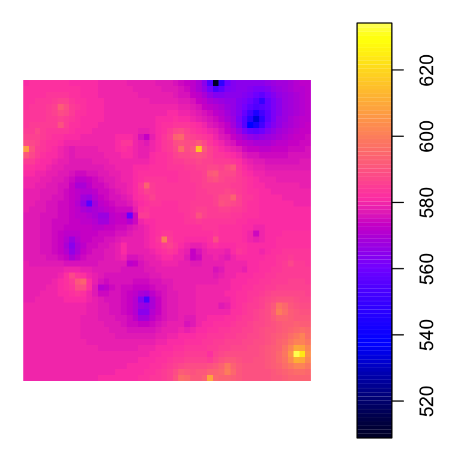

```r
idw_df <- as.data.frame(idw)

plot(idw)
```

```r
mapview(idw, zcol='var1.pred', layer.name = "year")
```

[interactive chart not shown]

```r
# I assume the jagged edges occure from converting to the equal distancw CRS?
```

### 3. Create a map of annual precipitation (column `year`) using ordinary kriging with constant intercept.

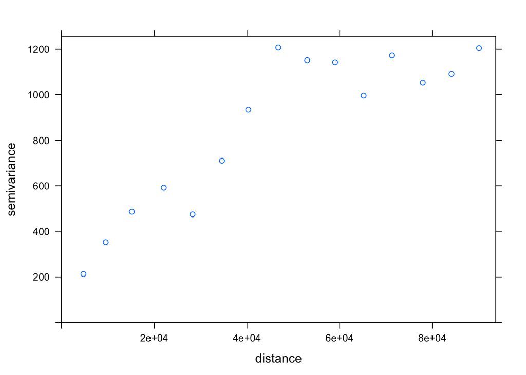

```r
rain_vario <- variogram(year ~ 1, data = rain_sp)

plot(rain_vario)
```

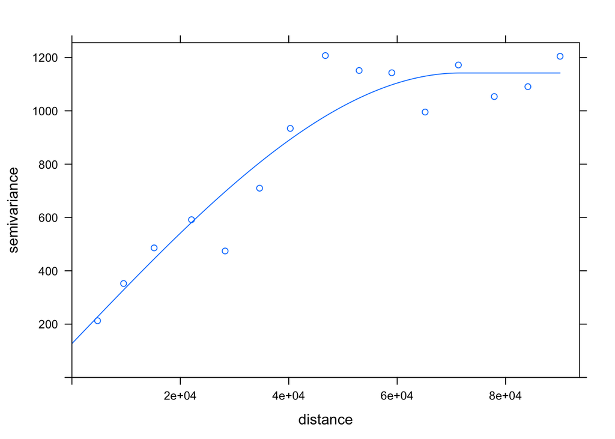

```r
rain_vario_fit <- fit.variogram(rain_vario, vgm(1, "Sph", 60000, 1))

plot(rain_vario, rain_vario_fit)
```

```r
# looks like a decent fit

rain_kriging <- krige(formula = year ~ 1, rain_sp, gridnew, rain_vario_fit)
```

```
## [using ordinary kriging]
```

```r
mapview::mapview(rain_kriging, zcol='var1.pred', layer.name = "year")
```

[interactive chart not shown]

```r
mapview::mapview(rain_kriging, zcol='var1.var', layer.name = "year")
```

[interactive chart not shown]